# Primeros pasos en R: ejercicio práctico

John Fredy Valbuena Lozano

**¡Antes de iniciar!**

Las carpetas de trabajo junto con el **script** *PrimerosPasos.R* que agrupa las funciones que se describirán a continuación se encuentran en el [repositorio GitHub: PrimerosPasos_R](https://github.com/jfredyval1/PrimerosPasos_R), descarguela y extraigala en su ordenador. Será de gran importancia para el correcto desarrollo de este ejercicio que descargue y ubique los datos de trabajo que se mencionan en **Adquirir de datos** en la carpeta *Datos*

# ¿Qué es `R` y por qué usarlo?

`R` es un lenguaje de programación multiparadigma, preferido para el desarrollo de flujos de trabajo ligados a la estadística, aunque cuenta con múltiples funcionalidades. `R` es usualmente trabajado en un entorno gráfico de desarrollo como *RStudio*, cuyo aspecto es mucho más amigable que la interfaz que trae por defecto el lenguaje. Se recomienda trabajar con ambos programas instalados. A continuación se encuentra la distribución que se encontrará por defecto una vez instalados los dos programas.

`R` al igual que `Python` es un lenguaje útil para el manejo de grandes volúmenes de datos siendo el primero mucho más amigable con quienes vienen de entorno relacionados con el pensamiento lógico matemático y el segundo, más apropiada para aquellos que han tenido algún tipo de acercamiento con el desarrollo de software o la ingeniería en general.

[figure not shown]

**Figura 1**: Distribución general del entorno `RStudio`

### Sintaxis básica en R

Como todo lenguaje `R` cuenta con algunas reglas iniciales para su correcta escritura y ejecución, sin embargo no son parámetros complicados, pero conocerlos si ahorrará algunos dolores de cabeza.

#### Creación de objetos

crear o almacenar un objeto al interior de `R` demanda de nombrarlo e indicar qué se guardará en su interior, probemos con un vector.

un objeto con nombre `resultado` guardará el producto de la suma `1 + 1`.

La sentencia `resultado <- 1 + 1` crea un objeto que contiene el resultado de esta operación.

Ahora, ¿cómo crear un objeto que contiene más de un carácter de su misma naturaleza, por ejemplo, un objeto que contiene más de un número? Veamos cómo se concatena un objeto.

`resultados<-c(1,2,3,4,5,6)`

Al imprimir este objeto se obtiene `[1] 1 2 3 4 5 6` indicando que el carácter `1` se encuentra en la posición uno del objeto `resultados`. Note que, además de contener más de un número, la secuencia se inicia con la letra `c` antes de entrar a nombrar los objetos contenidos en `resultados`, `c` siempre estará presente para estas operaciones y le indica al lenguaje que los elementos que presentará serán *concatenados* para crear un objeto.

Conocer la posición u orden de los elementos al interior de un objeto será de gran utilidad al momento de *indexar* datos en un objeto en particular. De igual forma cada símbolo tiene una finalidad específica al interior del lenguaje, durante el desarrollo del ejercicio notará cómo opera cada uno de ellos, por lo pronto conviene conocer cuales son los principales símbolos que se utilizan, estos son:

Bases de la sintaxis en R

| Símbolos | Funciones |
| --- | --- |
| <-,-> | Asignación |
| # | Comentarios |
| () | Argumentos de una función |
| [] o [[]] o $ | Para indexar, llamar partes de un objeto |
| {} | Agrupar expresiones |
| "" | Variables que necesitan ser representadas como caracteres tipo texto |

## ¿Qué podemos hacer?

La manipulación de información de diversas fuentes y formatos es un reto diario en la actividad curatorial, los volúmenes de información pueden variar, haciendo de esta tarea un ejercicio que puede ser rápido y sencillo o complejo y extenuante.

Ante ello se busca ofrecer una mirada rápida a los *procedimientos básicos* que pueden resultar más recurrentes. Se ha privilegiado para ello el uso del lenguaje de `R`, mediado por la interfaz `RStudio`. En caso de no contar con estos paquetes informáticos instalados en su ordenador puede darle una mirada rápida a este [**video**](https://www.youtube.com/watch?v=Nmu4WPdJBRo)

Sobre el entorno de `R` se abordarán las siguientes preguntas:

- ¿Cómo leer los datos en `R`?
- ¿Cómo resumir datos?
- ¿Cómo filtrar los datos?
- ¿Cómo exportar mis datos a un formato legible en excel?

## Adquirir datos

Para este caso trabajaremos con un conjunto de datos públicos, [*Eventos Minas Antipersonal en Colombia*](https://www.datos.gov.co/Inclusi-n-Social-y-Reconciliaci-n/Eventos-Minas-Antipersonal-en-Colombia/sgp4-3e6k), el alojamiento de este fichero nos ofrece de entrada información relevante sobre los datos, por ejemplo, se indica que cuenta con *14 columnas* y *37.151 filas* siendo cada una de ellas un *evento*.

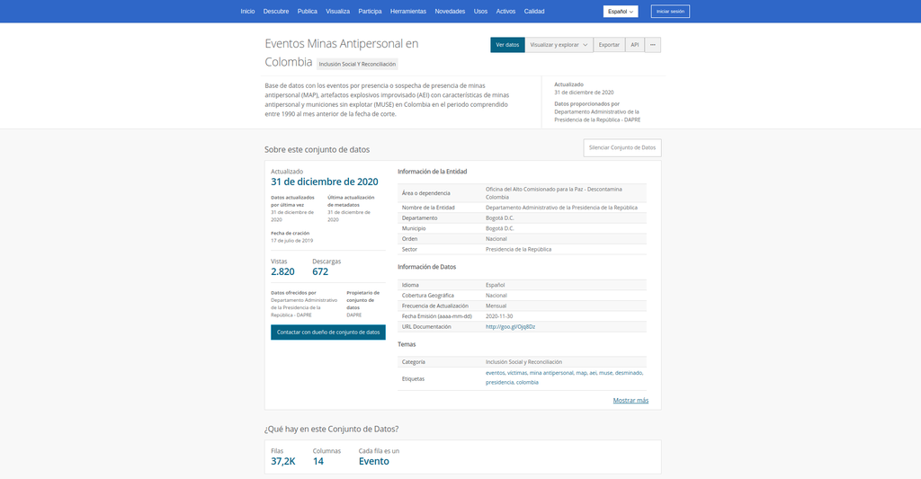

**Figura 2**: Alojamiento web de los datos

Ubicado el archivo es momento de encarar la primera pregunta, su flujo de trabajo inicial y vinculación al entorno de trabajo.

## ¿Cómo leer los datos en `R`?

La lectura de datos requiere de dos pasos previos de gran importancia:

- 0. Instalación de librerías necesarias
- 1. Vinculación de librerías
- 2. Conectar el conjunto de datos

### Instalación de librerías necesarias

Resulta usual que cada acción a realizar demande de una función específica, herramientas que por lo general hacen parte de una librería compuesta. Las funciones en este caso pueden ser consideradas *herramientas*, embebidas en librerías que a su vez hacen las veces de *Cajas de herramientas*.

Para instalar una librería ejecute esta sentencia sobre la consola: `install.packages("Nombre de lribería")`. Una vez realizado esto debe llamarla al entorno de trabajo, para esto puede usar la sentencia: `library(Nombre de la librería)`

La primero que se desea realizar es conectar los datos, leerlos en `R` y para ello tenemos dos opciones según el formato de los mismos. En el alojamiento web de los datos encontramos las opciones **Exportar** y **API**; inicialmente descargamos la información en formato *.csv* alojandola en la carpeta *Datos*, contenida en el archivo comprimido que fue descargado al inicio del ejercicio.

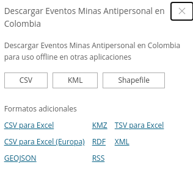

**Figura 3**: Formatos disponibles para la descarga de los datos

```r
######################################
## Lectura de datos en formato .csv ##
######################################

# Librería necesaria para ello
library(readr)
# conectar los datos
datos<-read_csv("Datos/Eventos_Minas_Antipersonal_en_Colombia.csv")
```

Una vez cargados los datos en `R` podemos hacer algunas preguntas de rutina sobre su naturaleza ¿Qué tipo de archivo es? ¿Cuántas y cuáles columnas tiene? ¿Podemos visualizarlo?

para estas tareas iniciales son de utilidad las siguientes órdenes

```r
# Identificar qué tipo de archivo es
typeof(datos)
```

```
## [1] "list"
```

```r
# Identificar nombre de columnas contenidas en los datos
names(datos)
```

```
##  [1] "TIPO_EVENTO"              "DEPARTAMENTO"
##  [3] "CODIGO_DANE_DEPARTAMENTO" "MUNICIPIO"
##  [5] "CODIGO_DANE_MUNICIPIO"    "AÑO"
##  [7] "MES"                      "EVENTO"
##  [9] "TIPO_LUGAR"               "TIPO_AREA"
## [11] "LATITUD_CABECERA"         "LONGITUD_CABECERA"
## [13] "SITIO"                    "UBICACION"
```

## ¿Cómo resumir los datos?

Una vez realizada esta exploración es posible formular preguntas al conjunto de datos que se ha obtenido, su nivel de detalle guiará la construcción de una o más sentencias específicas para su resolución: - ¿Qué departamento ha sido el más afectado por eventos relacionados con minas antipersonales? - ¿Cuál es el año en el que han predominado los reportes sobre estos eventos?

```r
# Departamento con mayor ocurrencia de estos fenómenos
table(datos$DEPARTAMENTO)
```

```
##
##           AMAZONAS          ANTIOQUIA             ARAUCA          ATLANTICO
##                  3               6183               2508                 16
##          BOGOTA DC            BOLIVAR             BOYACA             CALDAS
##                143               1766                401                483
##            CAQUETA           CASANARE              CAUCA              CESAR
##               3128                320               1944                406
##              CHOCO            CORDOBA       CUNDINAMARCA            GUAINIA
##                513                684                559                  9
##           GUAVIARE              HUILA         LA GUAJIRA          MAGDALENA
##                781               1006                168                117
##               META             NARIÑO NORTE DE SANTANDER           PUTUMAYO
##               5659               2333               2252               1638
##            QUINDIO          RISARALDA          SANTANDER              SUCRE
##                 57                 84               1070                170
##             TOLIMA    VALLE DEL CAUCA             VAUPES            VICHADA
##               1664                839                176                 71
```

Del ejemplo anterior se infiere la construcción que seguiría para responder la pregunta sobre la frecuencia de la columna `AÑO`. La función `table()` hace parte de las herramientas base incluidas en el lenguaje y se ocupa de generar una frecuencia para la columna seleccionada al interior de los datos, la señalización específica de esta columna está guiada por el signo dolar `$` el cual permite comunicar de manera específica la columna sobre la que operará la función.

```r
# Año y frecuencia de ocurrencia, eventos  minas antipersona
table(datos$AÑO)
```

```
##
## 1990 1991 1992 1993 1994 1995 1996 1997 1998 1999 2000 2001 2002 2003 2004 2005
##   35   52  171  200  255  208  163  146   76   81  232  351  975 1461 2029 1798
## 2006 2007 2008 2009 2010 2011 2012 2013 2014 2015 2016 2017 2018 2019 2020
## 2150 2029 1421 2667 2578 2928 3424 2783 2655 2335 1762  648  553  529  456
```

```r
# Almacenar esta información en un objeto aparte
FrecA<-table(datos$AÑO)
```

Esta vez no solo se ha consultado la tabla de frecuencia para la variable señalada, también se ha creado un objeto independiente que almacena esta información, la matriz `FrecA`. Pruebe qué sucede cuando reemplaza `<-` por `=` al momento de crear un objeto.

EL objeto creado tiene una particularidad, cuando en la consola se ingresa la sentencia `FrecA$` no se despliega una lista de opciones para manipular las columnas, una alternativa es convertir este objeto en un `data.frame()`

```r
# Convertir a data.frame
FrecA<-as.data.frame(FrecA)
```

Al ejecutar esta sentencia notará cómo el objeto ya creado pasa de estar agrupado en *values* a la categoría *Data*

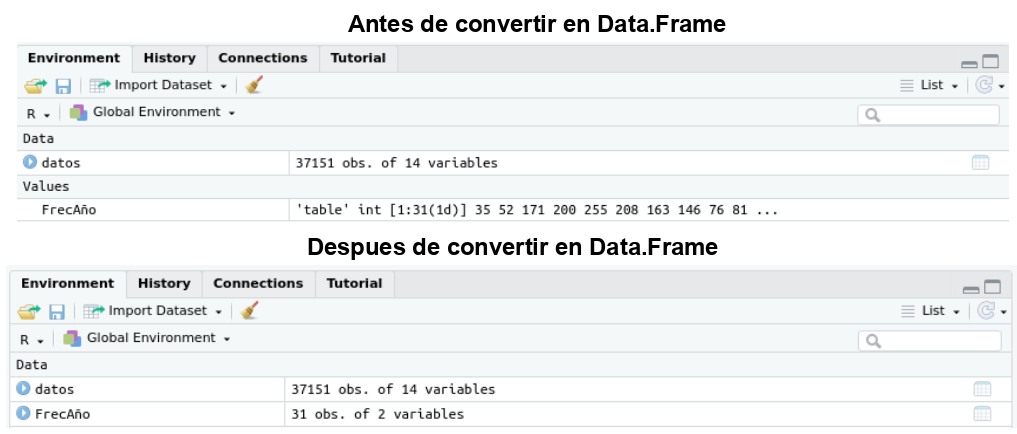

**Figura 4**: Transfromación de variable `FrecA` en `data.frame`

Algunos indicadores útiles al momento de conocer y describir una variable en particular está ligados a su cuantificación o bien a su participación porcentual sobre el total de datos, cada uno de estos indicadores es útil en casos particulares.

Conviene revisar cómo se crean nuevas columnas a datos existentes.

```r
###########################################
# Nuevas columnas en un conjunto de datos #
###########################################

# Frecuencia acumulada
FrecA$FrecAcum<-cumsum(FrecA$Freq)

# Porcentaje de ocurrencia por año
FrecA$Porcent<-prop.table(FrecA$Freq)*100

# Porcentaje acumulado de ocurrencia por año
FrecA$PorcAcum<-cumsum(FrecA$Porcent)
```

El signo dólar `$` es útil para llamar columnas existentes en el conjunto de datos, pero también permite crear y nombrar nuevas columnas al interior de los datos, los cálculos de frecuencia y porcentaje realizados anteriormente ejemplifican cómo utilizarlos en los dos casos.

Una vez calculados estos nuevos campos, es necesario explorar el conjunto de datos.

```r
# Ver conjunto de datos
print(FrecA)
```

```
##    Var1 Freq FrecAcum    Porcent     PorcAcum
## 1  1990   35       35 0.09421012   0.09421012
## 2  1991   52       87 0.13996931   0.23417943
## 3  1992  171      258 0.46028371   0.69446314
## 4  1993  200      458 0.53834352   1.23280665
## 5  1994  255      713 0.68638798   1.91919464
## 6  1995  208      921 0.55987726   2.47907190
## 7  1996  163     1084 0.43874997   2.91782186
## 8  1997  146     1230 0.39299077   3.31081263
## 9  1998   76     1306 0.20457054   3.51538317
## 10 1999   81     1387 0.21802912   3.73341229
## 11 2000  232     1619 0.62447848   4.35789077
## 12 2001  351     1970 0.94479287   5.30268364
## 13 2002  975     2945 2.62442465   7.92710829
## 14 2003 1461     4406 3.93259939  11.85970768
```

[output cut: 17 more lines]

**Nombrar las variables o los objetos con claves intuitivas es una práctica recomendable**, los datos anteriormente impresos muestran que las columnas 1 y 2 tienen nombres genéricos que no contribuyen a su comprensión `Var1` y `Freq` serán entonces reemplazadas por nombres mucho más acordes con la información que agrupan: `Año` y `Frecuencia`.

```r
# Cambio de nombre a columnas específicas
names(FrecA)[c(1,2)]<-c("Año","Frecuencia")
```

### Graficar los datos

Presentar los datos de manera tabular no siempre será una opción adecuada, para ellos existen diferentes formas para comunicar rápida y gráficamente algunas características de distribución dispuestas en el conjunto de datos. A continuación un ejemplo de ello.

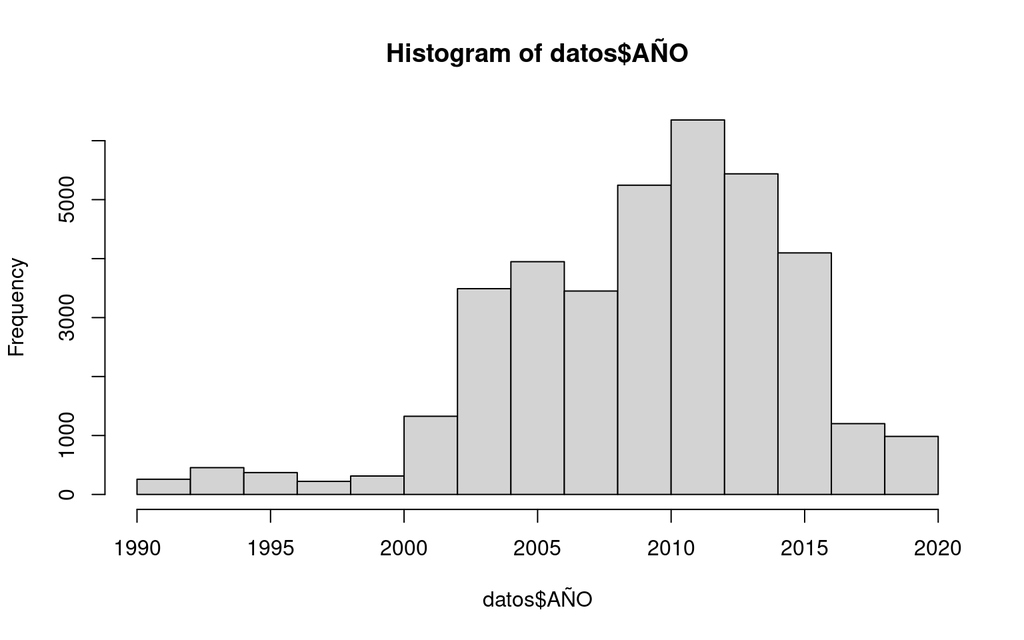

```r
#################################
# Graficar un conjunto de datos #
#################################

#Ejemplo 01: Histograma rápido
hist(datos$AÑO)
```

En el *Ejemplo 01* construye un histograma, presentando de una manera austera y sencilla la frecuencia de eventos presentados por año. La figura puede ser retocada para presentar de una manera más apropiada sus etiquetas, escala, colores y más, esto lo realiza la figura expuesta a continuación.

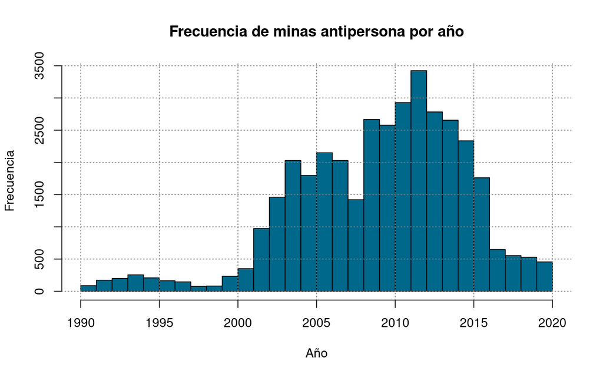

```r
#Ejemplo 02: Histograma

hist(datos$AÑO,
         breaks = 31, # Número de barras en las que se presenta la información
         main = "Frecuencia de minas antipersona por año", # Título de histograma
         xlab =   "Año", # Etiqueta para eje X
         ylab = "Frecuencia", # Etiqueta para eje Y
         col = "deepskyblue4", # Color de barras
         border = "black") # Color de borde de barras
# Lineas de ubicación sobre gráfico
grid(col = "gray50")
```

## ¿Cómo filtrar los datos?

Filtrar, seleccionar o segmentar los datos hace parte de un proceso específico de interrogación a los mismos, un conjunto de datos en particular puede ser dispuesto para apoyar la resolución de diferentes preguntas, comprender un fenómeno, apoyar conclusiones sobre el desarrollo de un determinado evento, entre otras.

Una vez creada la tabla resumen `FrecA` su información puede ser empleada para identificar datos que cumplan una condición específica de interés:

**Tomando en consideración que el periodo de registro contempla los años 1990 hasta 2020**, **¿Durante qué años y en donde se ubica el 40% de los registros agrupados en los datos colectados?**

La resolución de está pregunta en realidad solo demandará de dos sentencias, cada una ligada a procesos independientes pero relacionados:

- *Conectar la información resumida con los datos originales*
- *Identificar los datos que cumplen con la condición de hacer parte del 40% de los registros*

### Unir los registros tabulares

Es una operación sencilla, demanda de identificar una o más variables que dos tablas compartan, a partir de esto será posible unir la información de los dos conjuntos de datos en uno, esto a partir de *variables llave*

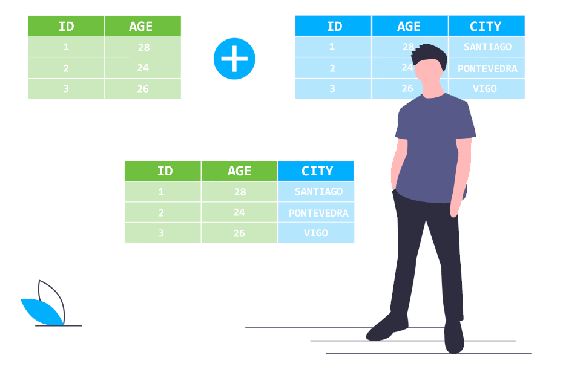

**Figura 5**: Ejemplo gráfico de funcionalidad en `merge()`

En este caso nos interesa que la tabla `datos` adquiera los valores de porcentaje acumulado calculados en el objeto `FrecA`, unión que se lleva a cabo a partir de la columna llave `Año`.

Antes de unificar esta información es posible identificar qué registros cumplen con la condición sugerida sobre su reporte inferior al 40%, para ello se crea una nueva columna con esta información agrupada en la tabla de datos resumidos `FrecA`.

```r
# Crear columna agrupando registros
FrecA$Agrupados[FrecA$PorcAcum<=40]<-"Registros menores al 40%"
FrecA$Agrupados[FrecA$PorcAcum>=40]<-"Registros mayores al 40%"

# Unir tablas a partir de columna "Año"
datosPorcAcum<-merge(datos,FrecA,  # Conjuntos de datos a unir
                     by.x = "AÑO", # Nombre de columna llave en objeto "datos"
                     by.y = "Año") # Nombre de columna llave en objeto "FrecA"

# Identificar columnas de "FrecA" que no aportan información sobre porcentaje acumulado ni agrupación
names(datosPorcAcum)
```

```
##  [1] "AÑO"                      "TIPO_EVENTO"
##  [3] "DEPARTAMENTO"             "CODIGO_DANE_DEPARTAMENTO"
##  [5] "MUNICIPIO"                "CODIGO_DANE_MUNICIPIO"
##  [7] "MES"                      "EVENTO"
##  [9] "TIPO_LUGAR"               "TIPO_AREA"
## [11] "LATITUD_CABECERA"         "LONGITUD_CABECERA"
## [13] "SITIO"                    "UBICACION"
## [15] "Frecuencia"               "FrecAcum"
## [17] "Porcent"                  "PorcAcum"
## [19] "Agrupados"
```

```r
# Eliminar columnas 15 a 17
datosPorcAcum<-datosPorcAcum[,-c(15:17)]

names(datosPorcAcum)
```

```
##  [1] "AÑO"                      "TIPO_EVENTO"
##  [3] "DEPARTAMENTO"             "CODIGO_DANE_DEPARTAMENTO"
##  [5] "MUNICIPIO"                "CODIGO_DANE_MUNICIPIO"
##  [7] "MES"                      "EVENTO"
##  [9] "TIPO_LUGAR"               "TIPO_AREA"
## [11] "LATITUD_CABECERA"         "LONGITUD_CABECERA"
## [13] "SITIO"                    "UBICACION"
## [15] "PorcAcum"                 "Agrupados"
```

Una vez adherida esta información a la tabla de datos principal es posible comunicar esta información, lo haremos inicialmente rediseñando el histograma general ya realizado, ahora se diferenciarán allí los registros que se acaban de agrupar.

**¡Importante! Se usará para este fin la librería ggplot2, asegúrese de instalarla antes de graficar el histograma**

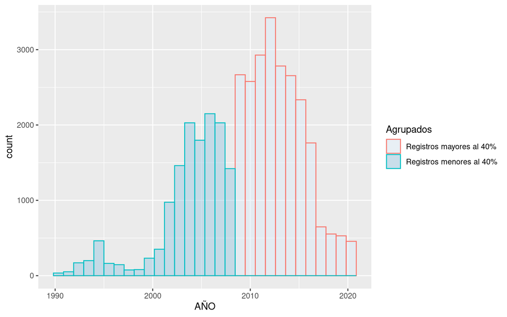

```r
# Librería a implementar
library(ggplot2)
# Histograma de frecuencias diferenciando datos agrupados
ggplot(datosPorcAcum, aes(x=AÑO, fill=Agrupados, color=Agrupados)) +
  geom_histogram(position="identity", alpha=0.5)+
        scale_fill_brewer()
```

Queda claro que el 40% de los eventos registrados se agrupan entre 1990 y 2008, siendo esta una clasificación general que permite construir una diferenciación inicial. Una vez realizado este procedimiento, comunicado de manera gráfica, la pregunta guía gira en torno a la ubicación de estos registros, sobre este punto se abren dos posibilidades de acuerdo con los insumos que el conjunto de datos ofrece:

- Clasificar los registros en unidades espaciales administrativas (Departamentos, Municipios)
- Utilizar la información de coordenadas para dar una idea inicial sobre su distribución espacial

En esta oportunidad se ejemplifica solo uno de los posibles tratamientos a la información.

### Información agrupada sobre el espacio

La información adquirida cuenta con registros útiles a la ubicación absoluta de los eventos, para ello se hará uso de la librería `leaflet`, cuyas herramientas permiten generar de manera sencilla una visualización dinámica sobre la ubicación de los eventos seleccionados.

```r
######################################
# Representar datos sobre el espacio #
######################################

# Librería
#En caso de no tener la librería instalada use la sentencia: install.packages("leaflet")

library(leaflet)

# Filtrar datos por agrupación
datos_xy<-datosPorcAcum[datosPorcAcum$Agrupados=="Registros menores al 40%",]

# Representar datos seleccionados en un mapa dinámico
leaflet() %>% # Entorno general de mapa dinámico
        addTiles() %>% # Adherir mapa base, por defecto Open Street Maps
        addMarkers(
        datos_xy$LONGITUD_CABECERA,datos_xy$LATITUD_CABECERA, # Ubicar según coordenadas
        clusterOptions = markerClusterOptions(), # Agrupar registros en clusters
        popup = datos_xy$TIPO_EVENTO) # Ventana emergente al click con información sobre tipo de evento
```

[interactive chart not shown]

Los elementos que se utilizan en la figura se encuentran clasificados en las siguientes categorías

```r
# Tipos de evento
print(table(datos_xy$TIPO_EVENTO))
```

```
##
##                Accidente por MAP               Accidente por MUSE
##                             4175                              177
##               Arsenal almacenada Desminado militar en operaciones
##                                8                             5403
##                    Incautaciones          Municiones sin explotar
##                             3225                               44
##    Producción de Minas (Fábrica)         Sospecha de campo minado
##                               28                              773
```

## Exportar datos

Una vez generado el flujo de trabajo propuesto es posible que sea de mayor utilidad exportar los datos resumen o los datos filtrados a un formato legible por Excel, el procedimiento para esta tarea es sencillo, mediante por una sentencia que creará el fichero en la ubicación que el usuario decida. En esta oportunidad se sugiere que el nuevo archivo repose en una de las carpetas que contienen el archivo **.zip** con el cual se ha venido trabajando.

```r
# Exportar datos tabulares a un formato legible por excel

 write_csv2(FrecA, file = "Resultados/Ejemplo1.csv") # guarda un archivo .csv legible en excel
```

## Concluciones y nuevas preguntas

Hasta aquí se han ejemplificado solo algunos de los procedimiento que es posible realizar en R, sin embargo otros tantos quedan por fuera, esto en función de las preguntas iniciales que han sido formuladas.

Además de ello es posible que quien realice esta guía inicial se esté preguntando

- ¿Será más eficiente generar frecuencias ancladas al nivel administrativo (Departamento, Municipio) en lugar del año?
- ¿Es posible obtener frecuencia y porcentajes acumulados que no dependan del año sino del aumento en el número de casos registrados?
- ¿Se pueden representar en un mapa dinámico solo los casos de los departamentos más y menos afectados?

Varios de estos cuestionamientos ya podrían ser resueltos, usando para ello las sentencias que se han desarrollado hasta aquí, generando los cambios que se consideren pertinentes, ejercitando así la creación de flujos de trabajo que permitan construir información novedoso y útil a partir de este u otros conjuntos de datos tabulares fácilmente trabajables en el entorno de programación que hasta aquí se ha presentado.